# Presentation-Butler slides

## Learning Uncertain Quantities for Data-Consistent Inversion: A Data-to-Distribution Pipeline

**T. Butler**

Co-authors: S. Mattis, K. Steffen, C. Dawson, and D. Estep

University of Colorado Denver  
troy.butler@ucdenver.edu

[*Learning Quantities of Interest from Dynamical Systems for Observation-Consistent Inversion*](https://www.sciencedirect.com/science/article/pii/S0045782521005582), Steven Mattis, Kyle Robert Steffen, Troy Butler, Clint N. Dawson, Donald Estep, Computer Methods in Applied Mechanics and Engineering, Vol. 388, 114230, (2022)

### Some references for the density-based approach

- [*Combining Push-Forward Measures and Bayes' Rule to Construct Consistent Solutions to Stochastic Inverse Problems*](https://epubs.siam.org/doi/abs/10.1137/16M1087229), T. Butler, J. Jakeman, T. Wildey, SIAM J. Sci. Comput., 40(2), A984–A1011 (2018)
- [*Convergence of Probability Densities using Approximate Models for Forward and Inverse Problems in Uncertainty Quantification*](https://epubs.siam.org/doi/abs/10.1137/18M1181675), T. Butler, J. Jakeman, T. Wildey, SIAM J. Sci. Comput., 40(5), A3523–A3548. (2018)
- [*Data-consistent inversion for stochastic input-to-output maps*](https://iopscience.iop.org/article/10.1088/1361-6420/ab8f83), T. Butler, T. Wildey, T.Y. Yen, Inverse Problems, 36, 085015, (2020)
- [*Convergence of Probability Densities using Approximate Models for Forward and Inverse Problems in Uncertainty Quantification: Extensions to $L^p$*](http://arxiv.org/abs/2001.04369), T. Butler, T. Wildey, W. Zhang, International Journal for Uncertainty Quantification, in-press (2022)

### Some related presentations

- T.Y. Yen, *Quantifying Aleatoric and Epistemic Uncertainties in RLC Circuits with Data-consistent Inversion*, 8-10 p.m., Tuesday, PP1
- T. Wildey, *A Probabilistic Characterization of Aleatoric and Epistemic Uncertainty in Solutions to Stochastic Inverse Problems Using Machine Learning Surrogate Models*, 3-3:25 p.m., Tuesday, MS17

## Why use Jupyter notebooks? It keeps me honest.

[figure not shown]

### There is more to this notebook than what is shown in the presentation.

You are invited to explore this and other notebooks at https://github.com/CU-Denver-UQ/LUQ.

### Some perspective (thanks Mark Twain!)

- Facts are stubborn, but statistics are more pliable.
- Most people use statistics like a drunk man uses a lamppost; more for support than illumination.
- ***Data is like garbage. You'd better know what you are going to do with it before you collect it.***

### Building Intuition

[figure not shown]

### A Motivating Example: "Cooking" a T-Bone

Step 1: Build a 3D model (5341 DOF, 23498 tetrahedral elements).

[video not shown]

Step 2: Determine thermal transfer properties of meat, bone, metal skillets, heated air, and typical temperature settings of stove tops.

Step 3: Follow (i.e., code) directions given by Omaha Steaks!

### A Motivating Example: "Cooking" a T-Bone

Representative steak simulated: Rare (blue), Medium rare (red), Medium-to-well done (brown)

[video not shown]

### The Snowflake (not millenials) Analogy

- Thermal properties are uncertain due to natural variability in livestock.
- Quantifying uncertainties in the thermal properties enables us to cook steaks more reliably to their desired doneness.

[figure not shown]

### Notation and Terminology

- $\lambda\in\Lambda$ = model inputs referred to as model parameters.
- $Q(\lambda)$ = measurable model outputs referred to as quantities of interest (QoI).
- $\mathcal{D} = Q(\Lambda)$ denotes the set of observable data that can be predicted by the model.
  - $q$ is used to denote a single datum.

### A pullback density: Existence, Uniqueness (up to initial), and Stability

$$ \large \pi_\Lambda(\lambda) = \pi_\Lambda^{initial}(\lambda) \frac{\pi_{\mathcal{D}}^{obs}(Q(\lambda))}{\pi_{\mathcal{D}}^{predict}(Q(\lambda))} $$

- Solving a ***forward UQ problem*** to approximate $\pi_{\mathcal{D}}^{predict}$ provides ***sufficient*** information to ***uniquely define*** $\pi_\Lambda$.
- **Predictability Assumption**: $\exists$ $C>0$ such that $\pi_{\mathcal{D}}^{obs}(q) \leq C\pi_{\mathcal{D}}^{predict}(q)$ for a.e. $q\in\mathcal{D}$.
- $\pi_\Lambda$ is ***stable*** (in the TV-metric) w.r.t. perturbations in $\pi_\Lambda^{initial}$ and $\pi_{\mathcal{D}}^{obs}$.
- The error in the approximate $\pi_\Lambda$ is bounded by the error in the approximate $\pi_{\mathcal{D}}^{predict}$ , i.e., the approximations are ***numerically stable.***

### Role of the set-valued inverses

$$ \large \pi_\Lambda(\lambda) = \pi_\Lambda^{initial}(\lambda) \frac{\pi_{\mathcal{D}}^{obs}(Q(\lambda))}{\pi_{\mathcal{D}}^{predict}(Q(\lambda))} $$

- $\pi_{\mathcal{D}}^{predict}$ and $\pi_{\mathcal{D}}^{obs}(Q(\lambda))$ are ***constant*** on each set-valued inverse $Q^{-1}(q)$.
- $\pi_\Lambda^{initial}(\lambda)$ serves to regularize the pullback only ***along*** on each set-valued inverse $Q^{-1}(q)$.
- $\pi_\Lambda(\lambda)$ is an update to $\pi_\Lambda^{initial}(\lambda)$ only in directions locally orthogonal to set-valued inverses.

### A simple example in Python: The Spaces, QoI, and Densities

- $\Lambda=[-1,1]$.
- $Q(\lambda) = \lambda^p$ for $p=5$.
- $\mathcal{D} = Q(\Lambda) = [-1,1]$.
- $\pi_{\Lambda}^{initial} \sim U([-1,1])$
- $\pi_{\mathcal{D}}^{obs} \sim N(\mu,\sigma^2)$
  - Initially take $\mu=0.25$ and $\sigma=0.1$.
- $\pi_{\mathcal{D}}^{predict}$
  - Known in this case.

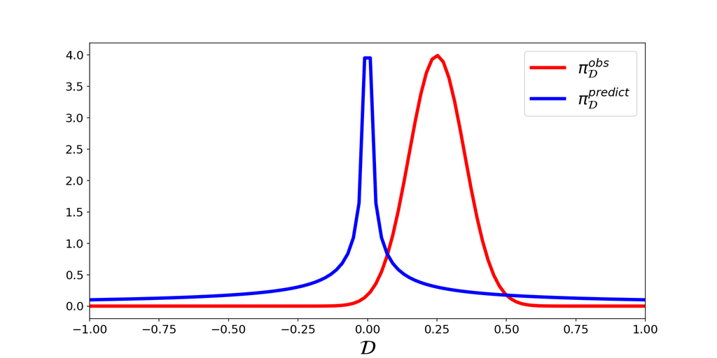

```python
fig = plt.figure(figsize=(12,6)) # Plot the push-forward of the initial and observed densities
qplot = np.linspace(-1,1, num=100)
observed_plot = plt.plot(qplot,norm.pdf(qplot, loc=mu, scale=sigma), 'r-', linewidth=4, label="$\pi_\mathcal{D}^{obs}$")
pf_initial_plot = plt.plot(qplot,1/10*np.abs(qplot)**(-4/5),'b-', linewidth=4, label="$\pi_\mathcal{D}^{predict}$")

plt.xlim([-1,1]), plt.xticks(fontsize=14), plt.yticks(fontsize=14),plt.xlabel("$\mathcal{D}$", fontsize=24), plt.legend(fontsize=20), plt.show();
```

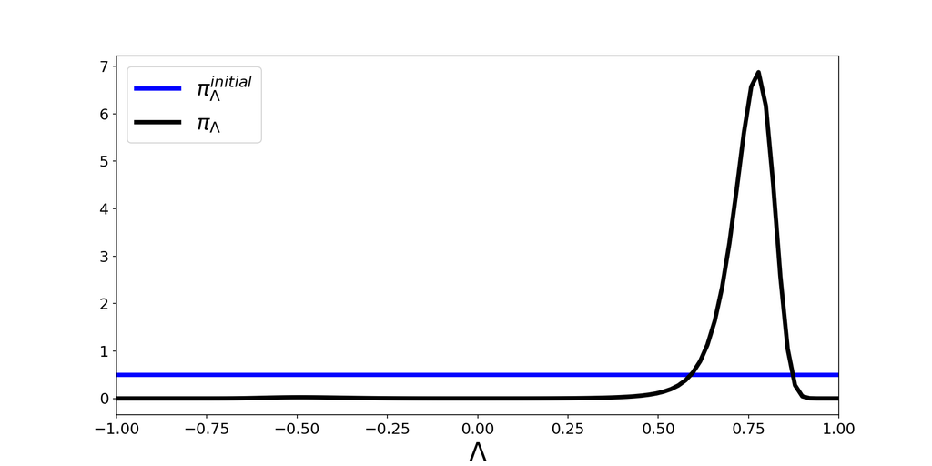

```python
fig = plt.figure(figsize=(12,6)) # Plot the initial and posterior
lam_plot = np.linspace(-1,1, num=100)
initial_plot = plt.plot(lam_plot,uniform.pdf(qplot, loc=-1, scale=2), 'b-', linewidth=4, label="$\pi_\Lambda^{initial}$")
pullback_plot = plt.plot(lam_plot,uniform.pdf(qplot, loc=-1, scale=2)*\
                         norm.pdf(QoI(lam_plot,5), loc=mu, scale=sigma)/(1/10*np.abs(QoI(lam_plot,5))**(-4/5)),'k-', linewidth=4, label="$\pi_\Lambda$")
plt.xlim([-1,1]), plt.xticks(fontsize=14), plt.yticks(fontsize=14), plt.xlabel("$\Lambda$",fontsize=24), plt.legend(fontsize=20), plt.show();
```

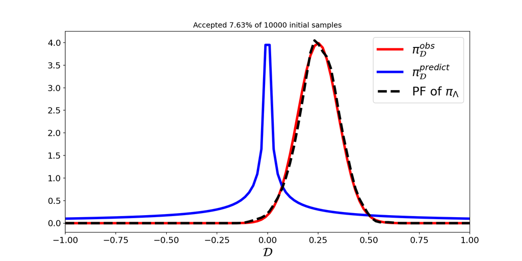

```python
plt.figure(figsize=(12,6)) # Plot the push-forward of the initial, observed density, and push-forward of pullback
qplot = np.linspace(-1,1, num=100)
observed_plot = plt.plot(qplot,norm.pdf(qplot, loc=mu, scale=sigma), 'r-', linewidth=4, label="$\pi_\mathcal{D}^{obs}$")
pf_initial_plot = plt.plot(qplot,1/10*np.abs(qplot)**(-4/5),'b-', linewidth=4, label="$\pi_\mathcal{D}^{predict}$")
pf_post_plot = plt.plot(qplot,postq_nl_kde(qplot),'k--', linewidth=4, label="PF of $\pi_\Lambda$")
plt.xlim([-1,1]), plt.xlabel("$\mathcal{D}$", fontsize=20)
plt.xticks(fontsize=14)
plt.yticks(fontsize=14)
plt.legend(fontsize=20)
title_str = 'Accepted %4.2f' %(post_q_nonlinear.size/N*100) +'% of ' + str(N) + ' initial samples'
plt.title(title_str), plt.show();
```

### A statistical Bayesian perspective

$$ {\pi}_\Lambda(\lambda \, | \, q) = \pi_\Lambda^{initial}\frac{ L(q\, |\, \lambda) }{C} $$

### A simple example in Python: Comparison to statistical Bayesian

We use the same initial and make the data likelihood function match the observed density.

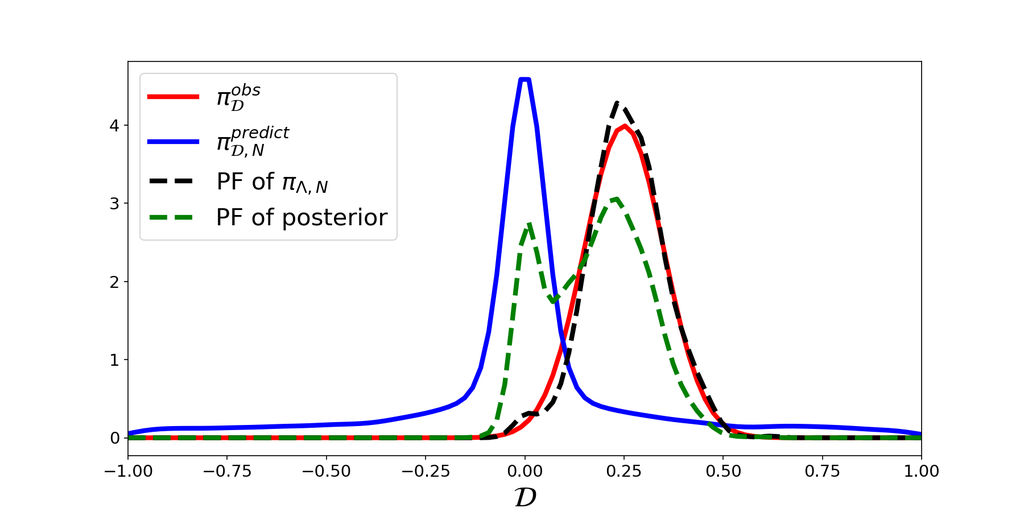

```
((-1.0, 1.0),
 None)
```

```python
plt.figure(figsize=(12,6)) # Plot the push-forward of the initial, observed density, and push-forward of pullback and stats posterior
qplot = np.linspace(-1,1, num=100)
observed_plot = plt.plot(qplot,norm.pdf(qplot, loc=mu, scale=sigma), 'r-', linewidth=4, label="$\pi_\mathcal{D}^{obs}$")
pf_initial_plot = plt.plot(qplot,q_nonlinear_kde(qplot),'b-', linewidth=4, label="$\pi_{\mathcal{D},N}^{predict}$")
pf_post_plot = plt.plot(qplot,postq_nl_kde(qplot),'k--', linewidth=4, label="PF of $\pi_{\Lambda,N}$")
pf_sb_post_plot = plt.plot(qplot,sb_postq_nl_kde(qplot),'g--', linewidth=4, label="PF of posterior")
plt.xticks(fontsize=14)
plt.yticks(fontsize=14)
plt.xlim([-1,1]), plt.xlabel("$\mathcal{D}$", fontsize=24), plt.legend(fontsize=20), plt.show()
```

### From data to QoI

***Data is like garbage. You'd better know what you are going to do with it before you collect it.*** - *Mark Twain*

- We have so far assumed that observable data is for some a priori specified QoI.
- What if we collect data but we do **not** know the QoI?
- Data is *not* the same thing as information and by itself is *not* interesting.
- In the era of *Big Data*, we often collect a lot of garbage and then go dumpster diving. Our apologies to Mark Twain.

### From data to QoI: Illustrative example

- $\Lambda = [-1,1]^2\subset\mathbb{R}^2$
- Dynamic response induced by parameters given by polynomial of unknown order.
- Observed data obtained at 10 Hz $[0,2]$ ($t$ assumed in seconds).

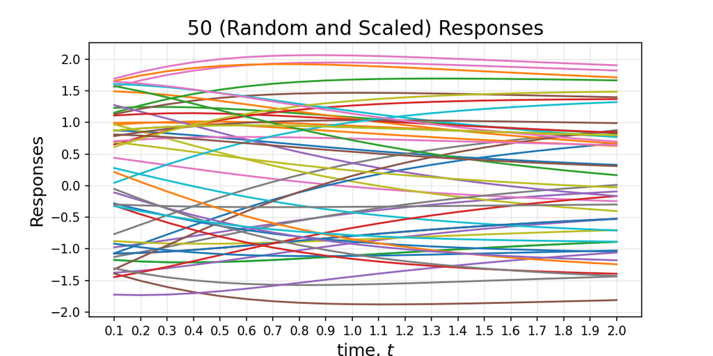

```python
data_scaled = StandardScaler().fit_transform(data) # scaling the samples
plt.figure(figsize=(8,4))
plt.plot(t[1:], data_scaled.T[:,np.random.choice(N,50)]);
plt.xlabel('time, $t$', fontsize=14), plt.ylabel('Responses', fontsize=14)
plt.xticks(t[1:]), plt.grid(True, linestyle=':', lw='0.5')
plt.title('50 (Random and Scaled) Responses', fontsize=16)
```

### From data to QoI: Illustrative example

- Use PCA to ***learn*** the number of interesting features in the data.

```python
interact(plot_gap,
         eig_vals = widgets.fixed(pca.singular_values_),
         n = widgets.IntSlider(value=1, min=0, max=5))
```

```
<function __main__.plot_gap(eig_vals, n)>
```

### From data to QoI: Illustrative example

- Construct the QoI map $Q(\lambda)$ from what we learned.

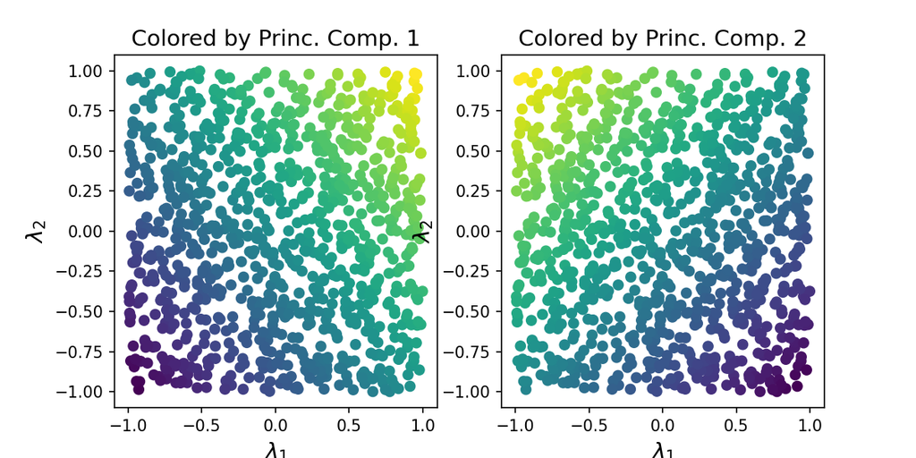

```python
## principal components plot ##
plt.figure(figsize=(8,4)), plt.subplot(1,2,1), plt.scatter(lam[:,0], lam[:,1], c = principal_components[:,0])
plt.xlabel("$\lambda_1$", fontsize=14), plt.ylabel("$\lambda_2$", fontsize=14)
plt.title("Colored by Princ. Comp. 1", fontsize=14)
plt.subplot(1,2,2), plt.scatter(lam[:,0], lam[:,1], c=principal_components[:,1])
plt.xlabel("$\lambda_1$", fontsize=14), plt.ylabel("$\lambda_2$", fontsize=14)
plt.title("Colored by Princ. Comp. 2", fontsize=14)
```

### Then what? (and many additional "what ifs")

- Proceed as usual *after* transforming all time series of data (predicted and observed) into samples of QoI from which $\pi_\mathcal{D}^{predict}$ and $\pi_\mathcal{D}^{obs}$ can be estimated.
- But, **what if**
  - the responses had no closed form (i.e., there is *no* polynomial),
  - and **what if** all we have are noisy measurements with uncertain levels of noise,
  - and **what if** bifurcations occur in the dynamical response as parameters vary in ways that are not known a priori,
  - and **what if** the noisy observable data and computational data are available at potentially different frequencies,
  - and **what if** these data have differing levels of noise,
  - and **what if** there were potentially missing data values in a given time window?
- Well, then we are in [`LUQ`](https://github.com/CU-Denver-UQ/LUQ)!

### Learning Uncertain Quantities ([`LUQ`](https://github.com/CU-Denver-UQ/LUQ)) is as easy as 1-2-3

- Step 1: Filter data (approximating dynamics) with adaptive piecewise linear splines
- Step 2: Clustering and classifying data (learning and classifying dynamics)
- Step 3: Feature extraction (learning quantities of interest)

### A typical LUQ implementation

Step 0: Create a LUQ object (the hidden step)

`from luq import LUQ # Import LUQ module`  
`learn = LUQ(predicted_time_series, observed_time_series, times)`

- Step 1: `learn.filter_data(**kwargs)`
- Step 2: `learn.dynamics(**kwargs)`
- Step 3: `predict_qoi, obs_qoi = learn.learn_qois_and_transform(**kwargs)`

### A simple example (harmonic oscillator): Step 2

[figure not shown]

### A simple example (harmonic oscillator): Step 3

[figure not shown]

### Not so simple examples (25 minutes just isn't enough time)

[*Learning Quantities of Interest from Dynamical Systems for Observation-Consistent Inversion*](https://www.sciencedirect.com/science/article/pii/S0045782521005582), has several other examples of interfacing [`LUQ`](https://github.com/CU-Denver-UQ/LUQ) with data-consistent inverse problems including

- the Sel'kov model of glycolysis that exhibits a Hopf bifurcation as we vary kinetic parameters,
- Burger's equation of a traveling wave exhibiting a shock forming at different speeds as we vary the initial condition,
- the Advanced Circulation (ADCIRC) model for the shallow water equations modeling the variability of water elevations as a function of uncertain wind drag parameters during a simulated extreme weather event in the Shinnecock Inlet off the coast of Long Island, NY, USA.

### Ongoing and future LUQ and DCI work

- Expanding LUQ to handle spatial and spatial-temporal data (utilizing deep-learning for the filtering step)
- Statistical analyses of finite observational data impacts on DCI solutions (utilizing Dirichlet processes for analyzing uncertainties in observed density approximations)
- Empirical distribution methods for DCI solutions (utilizing constrained quadratic programs to construct optimal $L^2$ approximations)
- Parameter estimation within DCI using Maximal Updated Density (MUD) points (utilizing analysis of residual distributions and comparing to Bayesian MAP estimates) ...

### Questions?

[figure not shown]